# A Universal Saver’s Match

Design, reach, generosity, and cost of a redesigned federal retirement-savings match

July 28, 2026

A universal, automatic retirement account paired with a redesigned federal match would extend a positive savings subsidy to roughly 44.5 million low- and moderate-income workers. Under automatic enrollment — the design’s central assumption — about 35.6 million would participate, at an estimated federal cost of about $19.1 billion per year.

**Why it matters.** The savings match enacted in federal law rewards only workers who already hold a workplace retirement account and who contribute enough to claim it. The binding flaw is not the size of the match but its delivery: it has nowhere to land for a worker who has no account, so the lowest earners — independent contractors, gig workers, and employees of firms that offer nothing — gain the least. Roughly three-fifths of the dollars the enacted match would otherwise direct to the bottom never arrive, because those workers lack the account the match must be deposited into. The design described here closes that gap by pairing the match with a savings account that every worker can use, raising the subsidy rate sharply at the bottom of the income scale, and lowering the amount a worker must set aside to receive the full credit.

## What the policy does

The proposal has two moving parts, and the first does most of the work. Every covered worker is automatically enrolled — at a default contribution of three percent of earnings — into a retirement account. Workers already covered by a qualifying workplace plan keep that plan; everyone else, including the self-employed and independent and platform workers, is routed into a new universal account modeled on a low-cost, portable federal design. The self-employed, who have no payroll to deduct from, reach the account through their estimated-tax payments or through the platforms they work on, under a safe harbor so that offering the benefit does not reclassify a contractor as an employee. This automatic account is what closes the access gap; it is the active ingredient, and the bulk of the program’s reach comes from supplying an account and a default contribution rather than from the size of the subsidy.

Second, the federal match itself is redesigned. Rather than a flat 50 percent match that stops at a fixed income cutoff, the match rate becomes a single declining line that depends on a worker’s income and tax-filing status. The rate begins at 200 percent for the lowest earners — one dollar of federal credit for every fifty cents saved — and falls steadily as income rises, reaching zero at the top of each eligibility band. The federal credit is capped at $1,000 per individual, so a married couple in which both spouses work can receive up to $2,000 between them; because the schedule is set by joint income but the cap applies per person, two equal earners are treated the same married or single.

Two design choices keep the match simple to administer and easy on work incentives. The match is computed on a worker’s *prior-year* income, so the amount is known when the contribution is made, requires no year-end reconciliation or clawback, and does not shrink because a worker earned a raise during the year. And a worker’s own contributions remain accessible — they can be withdrawn without penalty, as under a Roth account — so enrolling does not lock away savings a low-income household may need in an emergency; only the federal match carries a short holding period before it vests.

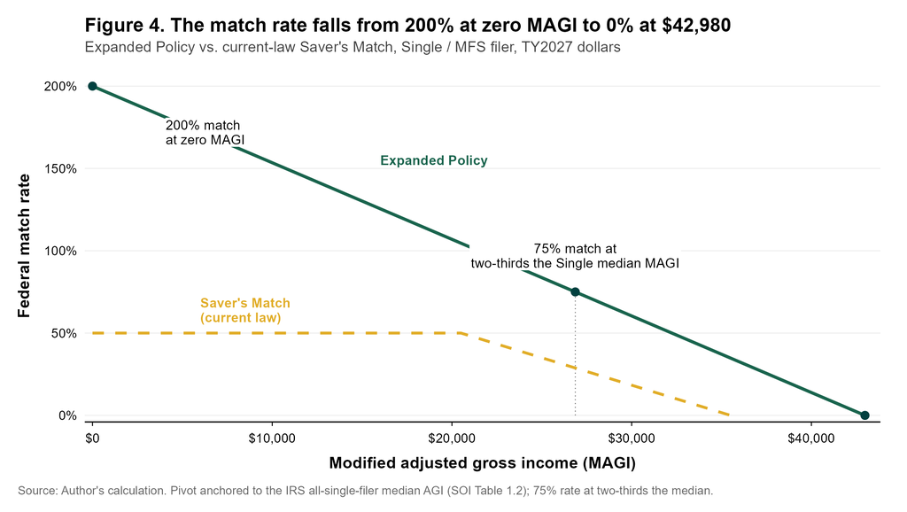

The redesigned match rate (solid green) against the current-law Saver’s Match (dashed gold), for a single filer. The current match is a flat 50 percent that ends at a low fixed cutoff; the redesign starts at 200 percent for the lowest earners and reaches far further up the income scale.

### Where the eligibility band falls

Each filing status has a *pivot* — the income level at which the match rate has declined to 50 percent. Below the pivot the rate is higher (rising to 200 percent at zero income); above it the rate keeps falling along the same line until it reaches zero, where the match ends. The same geometry applies to all three filing groups, scaled by the statutory ratios the enacted Saver’s Match already uses (head-of-household and joint bands are 1.5 and 2.0 times the single band).

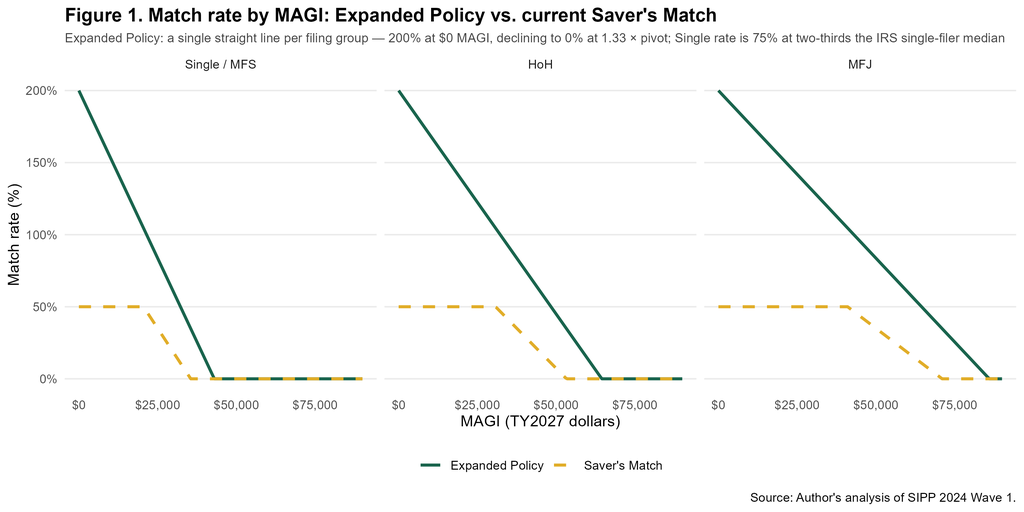

The redesigned match rate (solid) against the current-law Saver’s Match (dashed), by filing status. The redesigned rate is far higher at low incomes and reaches more of the distribution in every filing group.

| Filing status | Highest-match income | Income at a 50% rate (pivot) | Income where match ends |
| --- | --- | --- | --- |
| Single / married filing separately | $0 (200% rate) | $32,235 | $42,980 |
| Head of household | $0 (200% rate) | $48,353 | $64,471 |
| Married filing jointly | $0 (200% rate) | $64,471 | $85,961 |

## Who it reaches

The estimates rest on a large, nationally representative U.S. household survey that records each person’s earnings, income, household composition, and access to a workplace retirement plan. Survey weights are applied throughout so that every figure reflects the national population rather than the sample count.

The analysis begins with the roughly 259.9 million U.S. residents age 18 or older and narrows in steps to the working population the policy is built for: of those adults, about 156.7 million have earnings, and after setting aside dependents and full-time students and keeping only those with a determinable tax-filing status, a universe of about 145.3 million workers remains. Within it, an estimated 44.5 million workers — close to 31 percent of the universe — fall inside the redesigned eligibility band and would qualify for a positive match.

Eligible workers reach the match through one of two channels. Those who already hold a workplace plan claim it there; the rest reach it through the new universal account. The universal account carries the larger share of eligible workers, both because it absorbs self-employed workers and because workers without a plan at work tend to have lower incomes — and therefore higher match rates.

| Channel | Eligible workers | Average income | Average match rate |
| --- | --- | --- | --- |
| New universal account | 26.0 million | $34,768 | 85% |
| Existing workplace plan | 18.5 million | $41,301 | 66% |

The federal dollars land where the need is greatest. Of the full-participation match, an estimated 84 percent flows to the lowest-earning 30 percent of the workforce (the bottom three income deciles), and nearly all of it to the lower-earning half. The highest-income workers receive nothing, because the match phases out entirely before their income range begins.

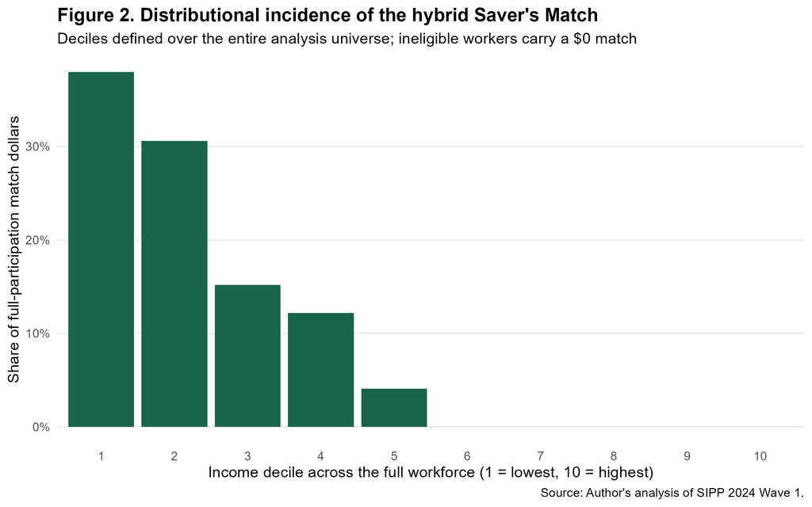

Share of federal match dollars by income decile across the full workforce (1 = lowest). The subsidy is weighted toward lower-income savers; higher deciles receive little or nothing.

## How generous it is

The redesign is most visible at the bottom of the income scale, where the current match does the least. Three measures make the point, using a single filer as the example.

- **A far higher subsidy rate.** At very low earnings the match rate is 200 percent, meaning a worker who sets aside just $500 receives the full $1,000 federal credit. The rate is still 100 percent at about $21,490 of income, where a $1,000 contribution — roughly 4.7 percent of earnings — captures the full credit.
- **An easier path to the maximum credit.** Under current law a worker must contribute the full $2,000 to receive the $1,000 maximum. Under the redesign, low earners reach the same maximum on a fraction of that amount, which matters because lower-income workers were never likely to set aside $2,000.
- **A larger average award.** Across all participants the redesign delivers an average federal match of about $537 per year, set against roughly $278 per worker under the current-law match at full participation in the same population.

The high rate at the bottom is a deliberate choice. A dollar is hardest to move out of day-to-day consumption for the lowest earners, so the schedule over-matches there — a 200 percent rate — to make a small contribution worth enough to pull a household into saving at all. The two figures below trace what that means for the worker’s side of the bargain: how much a single filer must set aside to capture the full $1,000 credit, in dollars and as a share of earnings.

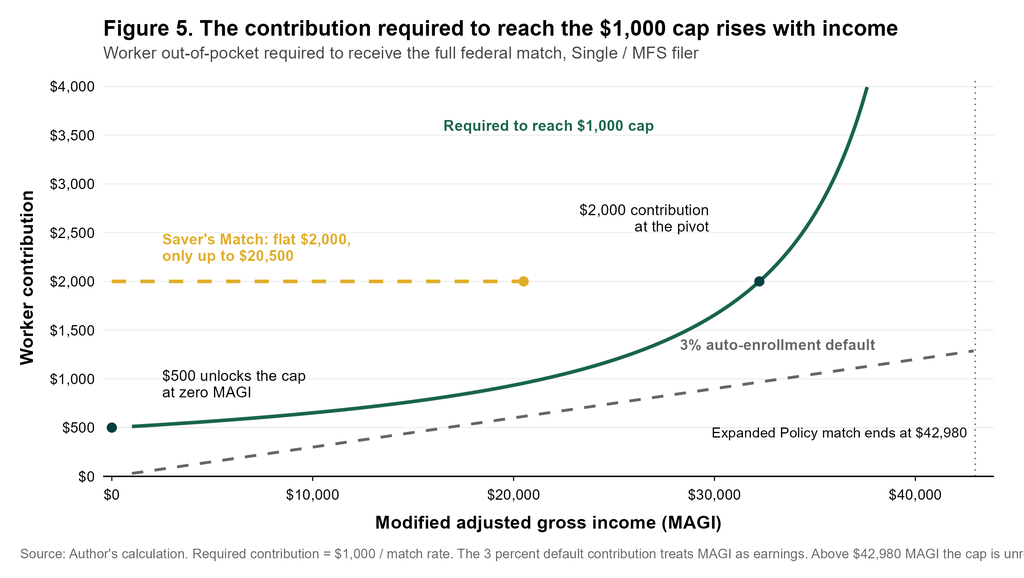

The out-of-pocket contribution needed to receive the full $1,000 match. At the bottom of the band just $500 unlocks it; the required amount rises with income to $2,000 at the pivot and then climbs out of reach as the match rate falls toward zero. The current-law match (gold) requires the full $2,000 and only below a low fixed cutoff.

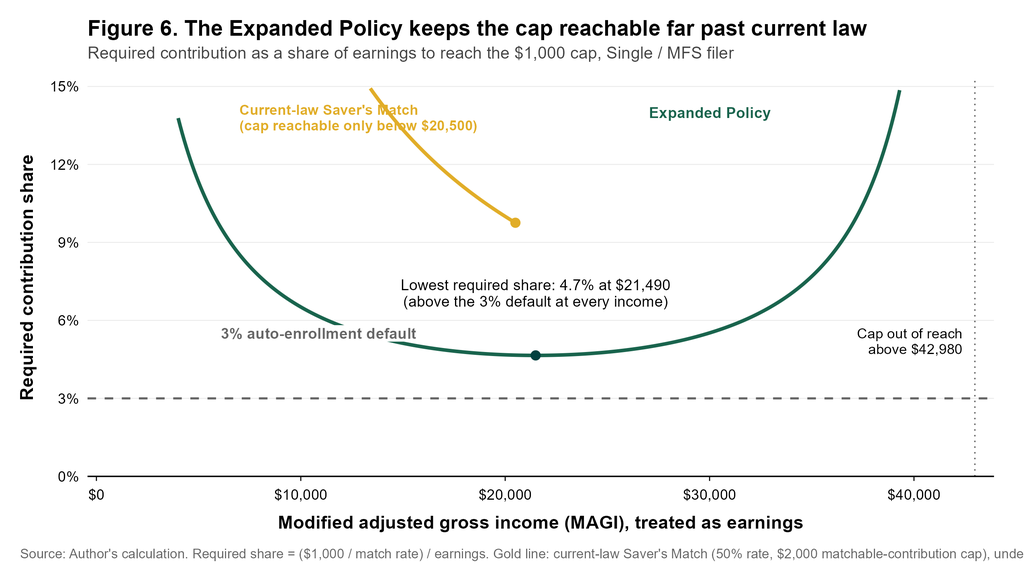

The same requirement as a share of earnings is U-shaped, bottoming at about 4.7 percent of earnings near $21,490 of income — just above the three percent automatic default, so a worker who nudges their contribution a little above the default captures the full credit across the middle of the band. Under current law (gold) the cap is reachable only at the very bottom.

## What it costs

The central estimate is an annual federal cost of about $19.1 billion, reaching 35.6 million participating savers at an automatic-enrollment participation rate of 80 percent. Participation is the single largest driver of cost, so the estimate is best read as a range. The lower bound applies the participation rate observed today among workers who already have plan access (about 59 percent) — a figure the evidence on automatic enrollment suggests understates how many workers stay in a sticky payroll default, which is why the 80 percent auto-enrollment case is taken as the headline rather than the floor. The upper bound assumes every eligible worker participates.

| Participation scenario | Take-up | Participants | Annual cost |
| --- | --- | --- | --- |
| Observed participation behavior (lower bound) | 59 percent | 26.2 million | $14.1 billion |
| Automatic enrollment at 80 percent (headline) | 80 percent | 35.6 million | $19.1 billion |
| Full participation (upper bound) | 100 percent | 44.5 million | $23.9 billion |

Two features of the cost range stand out. The structural ceiling — the cost if every eligible worker participated — is about $23.9 billion, so the program cannot cost more than that at any plausible behavioral response. And because the match is paid only on the contributions workers actually make, cost tracks participation closely: the program’s reach, and its price, both depend on the automatic account doing its job. These figures are gross transfer costs. Over a longer horizon part of that cost is recovered: workers who reach retirement with more savings draw less on means-tested programs such as Medicaid and Supplemental Security Income, an offset a budget-model analysis of the closely related Retirement Savings for Americans Act estimated grows large enough to turn that proposal net-positive after several decades. The cap on the per-person credit here bounds the gross cost well below that proposal’s, so the same direction of offset should apply at lower expense.

### How it compares with current law

|  | Current-law Saver’s Match | This proposal |
| --- | --- | --- |
| Match rate at the bottom | 50% | Up to 200% |
| Income thresholds | Fixed dollar cutoffs | Anchored to the IRS median by filing status |
| Eligible workers | 33.1 million | 44.5 million |
| Federal cost | $9.2 billion | $23.9 billion |
| Average match per worker | $278 | $537 |

Both columns apply the same working population at full participation, so the difference reflects design alone — a higher subsidy rate at the bottom, an income-anchored band reaching more workers, and a larger average award.

## Scenario add-on: an automatic $100 seed contribution

A match, however generous, reaches only workers who contribute. As a scenario extension, the model adds an automatic $100 annual federal contribution deposited into the account of every eligible worker — whether or not the worker contributes anything of their own. The seed does not count toward the $1,000 match cap, and because it is unconditional its cost does not depend on the participation assumption.

Three results summarize the scenario:

- **Reach.** The seed reaches all 44.5 million eligible workers in every scenario. Under the headline 80 percent auto-enrollment case, that includes about 8.9 million eligible workers who would not be contributing and would therefore receive no match at all — the seed is the only federal retirement dollar that reaches them, and it arrives in an account that then exists to receive a tax refund, a windfall, or a future raise.
- **Cost.** The seed adds about $4.4 billion per year at any participation rate, raising the headline total from $19.1 billion to $23.5 billion and the full-participation ceiling to $28.3 billion.
- **Distribution.** Because the seed is a flat amount per person, its dollars follow the eligible population rather than contribution size: an estimated 79 percent of seed dollars flow to the lowest-earning 30 percent of the workforce, and the seed is relatively most important exactly where match dollars are smallest — for workers whose contributions, and therefore matches, are near zero.

| Participation scenario | Match cost | Seed cost | Total including seed |
| --- | --- | --- | --- |
| Observed participation behavior (lower bound) | $14.1 billion | $4.4 billion | $18.6 billion |
| Automatic enrollment at 80 percent (headline) | $19.1 billion | $4.4 billion | $23.5 billion |
| Full participation (upper bound) | $23.9 billion | $4.4 billion | $28.3 billion |

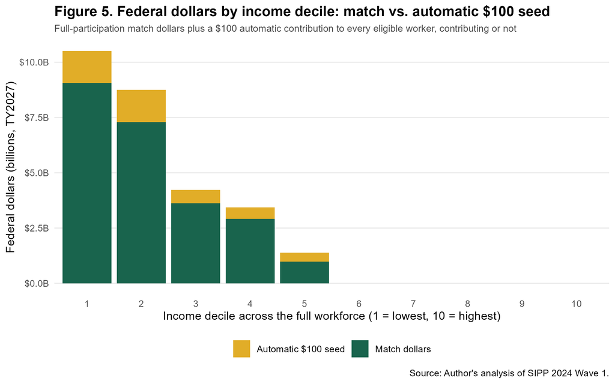

Federal dollars by income decile across the full workforce, decomposing the full-participation match (green) and the automatic $100 seed (gold). The seed is small against the match in dollar terms, but it is the only component that reaches eligible workers who do not contribute.

The case for the seed is not the size of the first-year benefit — $100 is a modest sum — but account formation: it guarantees that every eligible worker ends the year with a funded retirement account, shifting the remaining policy problem from opening accounts to growing balances, which a future Congress could address by raising the contribution. The caveat travels in the other direction: an automatic deposit requires the universal account infrastructure to reach workers the payroll system does not, so the seed’s administrative burden is concentrated on exactly the workers who are hardest to enroll.

### Phasing the seed instead of ending it abruptly

The flat design has one rough edge: a worker just inside the eligibility band receives the full $100 while a worker one dollar above it receives nothing. Three phased variants remove that cliff in different ways, trading cost against how many workers keep the full amount. A *pro-rata* seed scales with the match rate itself, declining from $100 at zero income along the same line as the match. A *flat-then-taper* seed pays the full $100 up to the pivot — the income where the match rate has fallen to 50 percent — and then declines to zero at the match endpoint, mirroring the geometry of the current-law Saver’s Match. An *extended-taper* seed pays the full $100 across the entire eligible band and phases out beyond it, so no eligible worker loses anything relative to the flat design and workers just above the band receive a partial seed.

| Seed design | Annual cost | Recipients | Receive the full $100 | Share of seed dollars to the bottom 30% |
| --- | --- | --- | --- | --- |
| Flat $100 (headline) | $4.4 billion | 44.5 million | 44.5 million | 79 percent |
| Pro-rata with match rate | $1.7 billion | 44.5 million | — | 91 percent |
| Flat, then taper | $3.6 billion | 44.5 million | 28.1 million | 85 percent |
| Extended taper | $5.3 billion | 60.3 million | 44.5 million | 74 percent |

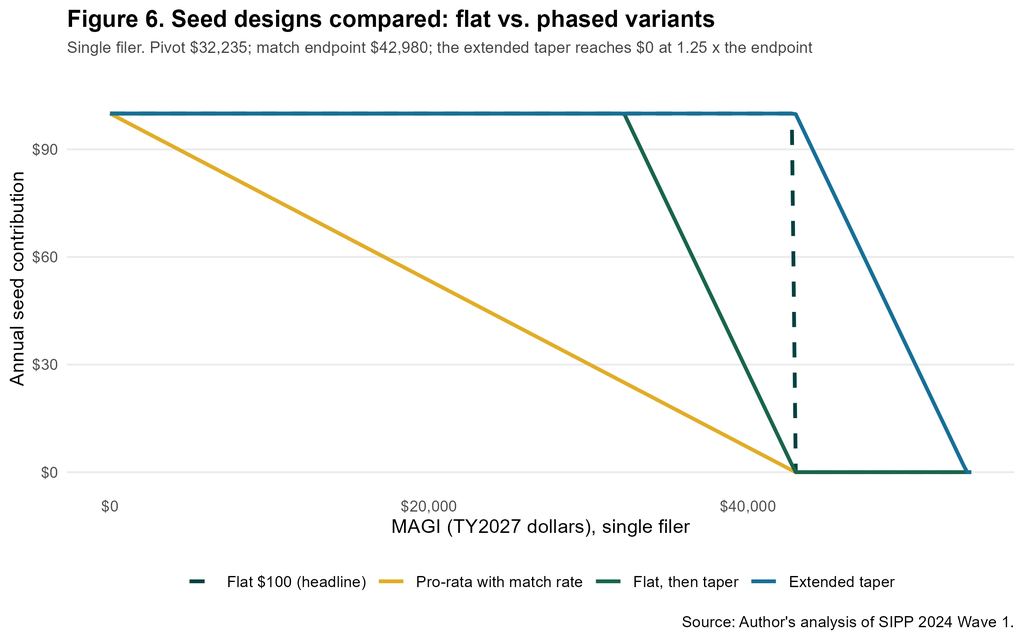

The four seed designs for a single filer. The flat design stops abruptly at the match endpoint; the phased variants remove the cliff by declining inside the band (pro-rata, flat-then-taper) or by extending past it (extended taper).

## How the estimates were produced, and what to keep in mind

The cost and reach figures come from a microsimulation: the policy rules are applied to each worker in the survey, the federal match is computed for that worker given their income, filing status, and savings channel, and the results are summed using national population weights. Incomes are projected forward to the policy’s first effective tax year using a standard wage-growth assumption so that the dollar thresholds line up with the year the policy would take effect.

A few assumptions shape the numbers and should travel with them. The estimates are descriptive: they show what the policy rules would cost and whom they would reach under stated participation assumptions, not a behavioral forecast of how saving or work decisions might change. Participation is the largest source of uncertainty, which is why the cost is reported as a range; and the federal match is paid only on contributions workers actually make, so the estimates assume the automatic three percent default is contributed. They also do not model how employers might respond — in particular, whether some small firms would drop their own plans once a subsidized universal account exists, a displacement risk that independent analyses of similar federal-account proposals have flagged and that would reduce net new saving. Because the underlying data are a sample of households, the figures are point estimates rather than exact counts and carry no statistical confidence intervals, so small differences should not be over-interpreted. The eligibility band is anchored to administrative IRS income data, but each worker’s income is measured in a household survey that approximates — and is drawn from a somewhat different population than — the tax records a revenue agency would use, so a tax-administered version would shift the counts modestly; the survey’s incomes are aged forward to the policy’s first year for dollar comparability, but the population’s composition and behavior are not re-projected. Finally, the design’s withdrawal rules follow the portable-account model of pending legislation — a worker’s own contributions stay accessible, while the federal match must season briefly before it vests — but the leakage those rules permit, the cost of administering the universal account, and the standing up of that account are not separately modeled here; each matters for an implementing statute more than for the headline transfer cost.

Source: Author’s analysis of a nationally representative U.S. household survey (2024), projected to the policy’s first effective tax year. All population figures are survey-weighted. Costs are annual and expressed in current dollars. Figures reflect the most recent model run and may update as inputs are refreshed.